# Single-cell profiling identifies ACE+ granuloma macrophages as a non-permissive niche for intracellular bacteria during persistent Salmonella infection

## Background

This is a jupyter notebook for the manuscript:  
**Single-cell profiling identifies ACE+ granuloma macrophages as a non-permissive niche for intracellular bacteria during persistent Salmonella infection. Trung H. M. Pham†‡, Yuan Xue†, Susan M. Brewer, Kenneth E. Bernstein, Stephen R. Quake‡, Denise Monack‡. [Science Advances (2023)](https://www.science.org/doi/full/10.1126/sciadv.add4333).**

Legends: †: co-first authors. ‡: co-corresponding authors.

## Accessing code and data to reproduce analysis of this notebook

Github repository associated with this notebook:

https://github.com/xuesoso/2022_ACE_Granuloma_Macrophage

1. You can clone this repository to your local computer with:

   `git clone https://github.com/xuesoso/2022_ACE_Granuloma_Macrophage`
2. In `README.md`, you will find instructions on how to access the raw and processed data, and analysis code used in this notebook.
3. To follow the notebook, the fastest way to access the processed data is through the [shared Google Drive](https://drive.google.com/drive/folders/1ohx-A5gmWS42yG77ee6h7KLyaY4CINQV?usp=share_link) or [Dryad deposit](https://datadryad.org/stash/dataset/doi:10.5061%2Fdryad.ksn02v77w). Download `data.zip` and unzip the contents to the data directory inside this repository:

   `cd 2022_ACE_Granuloma_Macrophage/`

   `unzip data.zip -d ./data/`

## Installing the dependencies to run this notebook

**Two options to build the packages required by the code in this notebook**:

1. The easiest way is to build the Docker image with the Dockerfile provided in this repository and run the Jupyter notebook inside a container.
   - Required: [Install Docker](https://docs.docker.com/get-docker/)

   Once you have Docker installed, navigate to the local directory of this Github repository:

   `cd 2022_ACE_Granuloma_Macrophage/`

   Execute the script to build the image with pre-specified configurations:

   `bash ./Docker/build_docker.sh`

   Execute the script to run this notebook under the Docker container:

   `bash ./Docker/run_docker.sh`

   Navigate to the local address of the Jupyter notebook on your favorite browser, the default port passed is set to `8887`:

   `firefox http://localhost:8887/notebooks/notebook/analysis_notebook.ipynb`
2. The second approach is to manually install the exact library versions. **This is not recommended as it involves navigating a complicated dependency graph**:
   - Install [Anaconda v4.8.3 with python 3.8](https://repo.anaconda.com/miniconda/Miniconda3-py38_4.8.3-Linux-x86_64.sh) on Linux system (tested on Ubuntu 18.04/Fedora 36).
   - Execute in shell: `conda install -c conda-forge install python=3.7.0`
   - Install the exact version of python packages with `pip` as documented in `requirements.txt`
   - Note: You may have to install different dependent packages than the latest versions recommended by your platform's package manager.

## Load dependent libraries

```python
%load_ext autoreload
%autoreload 2
%matplotlib inline
import sys
sys.path.insert(0, '../')
from src.python.variables.granuloma_lib import *
import visualization.plot as pl
import src.python.scripts.analysis as analysis
plt.style.use('default')
```

Check and make sure we have all processed input data

```python
ls $infd
```

```
201221_10X_velocyto_all.h5ad
ABCT_SAM_momac.220828_review.h5ad
harmony.sam_T_C_treatment.200119.sam_full.210505.h5ad
sam_full.210505.h5ad
sam_full_velocyto.210505.h5ad
sam_macrophageSubset_AB.210919.h5ad
sam_monocyteSubset.210505.h5ad
sam_monocyte_velocyto.210505.h5ad
sam_myeloidSubset.210505.h5ad
```

## Load scRNA-seq data of all immune cells from WT (A) + $\Delta$*STeE* (B) STm infected mice

### Figure 1A: UMAP of immune cell population showing cell type annotations

```python
fn = infd+'sam_full.210505.h5ad'
adh = sc.read_h5ad(fn)
```

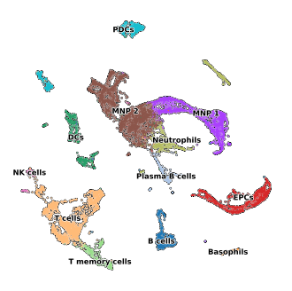

```python
fig, ax = plt.subplots(figsize=(4, 4))
sc.pl.umap(adh, color='label', legend_loc='on data', legend_fontsize=6,
        s=5, frameon=False, ax=ax, title='', legend_fontoutline=1, add_outline=True)
sfig(fig, fdm+'1A.umap_full_ann_outline')
```

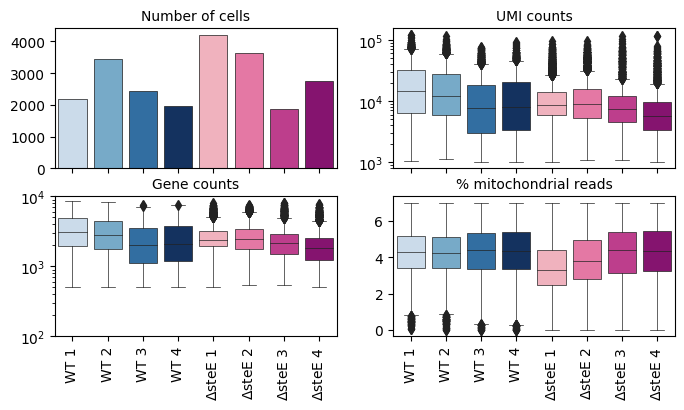

```python
#### SFig1 - quality check metrics
qcmetrics = ['read_sum', 'gene_counts', 'pct_counts_mt']

dtcmap = {dt[x]:cmap[x] for x in set(adh.obs['treatment'].values)}
adh.obs['batch_label'] = [dt[x[0]]+' '+x[1] for x in adh.obs['batch']]
order = [dt[x[0]] + ' ' + x[1] for x in sorted(set(adh.obs['batch']))]
top = mpl.cm.get_cmap('Blues', 128)
bottom = mpl.cm.get_cmap('RdPu', 128)
newcolors = np.vstack((top(np.linspace(0.25, 1, 4)), bottom(np.linspace(0.35, 0.8, 4))))
tmp = adh.obs.groupby('batch_label').count().reset_index()
fs = 10

fig, axs = plt.subplots(figsize=(8, 4), ncols=2, nrows=2, sharex=True)
axs = axs.flatten()
sns.barplot(data=tmp, ax=axs[0], x='batch_label', y='batch', order=order,
        palette=newcolors, linewidth=0.5, edgecolor='k')
sns.boxplot(data=adh.obs, ax=axs[1], x='batch_label', y='read_sum',
        linewidth=0.5, order=order, palette=newcolors)
sns.boxplot(data=adh.obs, ax=axs[2], x='batch_label', y='gene_counts',
        linewidth=0.5, order=order, palette=newcolors)
sns.boxplot(data=adh.obs, ax=axs[3], x='batch_label', y='pct_counts_mt',
        linewidth=0.5, order=order, palette=newcolors)
axs[1].set_yscale('log');
axs[2].set_yscale('log');
axs[1].set_yticks([1e3, 1e4, 1e5]);
axs[2].set_yticks([1e2, 1e3, 1e4]);
axs[0].set_title('Number of cells', fontsize=fs)
axs[1].set_title('UMI counts', fontsize=fs)
axs[2].set_title('Gene counts', fontsize=fs)
axs[3].set_title('% mitochondrial reads', fontsize=fs)
for ax in axs:
    ax.tick_params(axis='x', rotation=90, labelsize=fs)
    ax.tick_params(axis='y', labelsize=fs)
    ax.set_xlabel('');
    ax.set_ylabel('');
sfig(fig, fdm+'s1A.boxplot_gc_rs_mt_pct')
```

### Figure 1B: Boxplot of cell type frequency

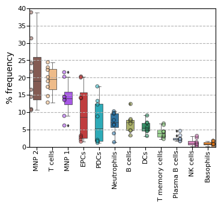

```python
groups_order = ['PDCs', 'B cells', 'NK cells', 'T memory cells', 'EPCs',
        'Plasma B cells', 'T cells', 'Basophils', 'Neutrophils', 'MNP 1', 'DCs', 'MNP 2']
_cta_ = 'label'
obs = adh.obs[[_cta_, 'batch']].copy()
dtcmap = {dt[x]:cmap[x] for x in cmap}
df_abundance = obs.groupby([_cta_, 'batch']).size().unstack().fillna(0)
df_abundance = df_abundance.loc[groups_order]
Dpivot = df_abundance.div(df_abundance.sum(axis=0), axis=1)*100
Dpivot.columns = [dt[x[0]]+' '+x[1] for x in Dpivot.columns]
D = Dpivot.stack().reset_index()
D.columns = ['cluster', 'group', 'frequency']
D['group'] = [x.split(' ')[0] for x in D['group']]
hue_order = list(dt.values())
order = D.groupby('cluster')['frequency'].mean().sort_values()[::-1].index

df_sum = df_abundance.sum(1).sort_values()[::-1]
df_fraction = df_sum / df_sum.sum() * 100
_cmap_ = {y:'{:}'.format(adh.uns['label_colors'][x]) for x, y in enumerate(np.unique(adh.obs['label']))}
c = [_cmap_[x] for x in df_sum.index]

fig, ax = plt.subplots(figsize=(4, 3))
gfg = sns.boxplot(data=D, x='cluster', y='frequency', ax=ax, width=0.5,
        linewidth=0.5, fliersize=2, orient='v', order=order, palette=c)
ax = sns.stripplot(x="cluster", y="frequency", data=D, edgecolor='k',
        linewidth=1, alpha=0.5, ax=ax, jitter=True, palette=c,
        dodge=True, marker='o', size=4, order=order)
ax.set_xlabel(''); ax.set_ylabel('% frequency', fontsize=10);
ax.set_ylim(0, 40)
gfg.tick_params(labelsize=8, top=False, pad=0)
ax.set_xticklabels(ax.get_xticklabels(), minor=False, rotation=90);
ax.grid(axis='y', which='major', linestyle='--');
sfig(fig, fdm+'1B.boxplot_full_frequency.vertical')
```

### Figure 1C: Dotplot of immune population marker genes

Load the marker genes based on negative binomial differential test of all clusters found in the immune population.

```python
l2thres, pthres, min_expressed = 1, 0.05, 0.5
fns = glob(infd+'../marker/Full.label/negative_binomial/*.tsv.gz')
nbmarker_full = {}
for fn in fns:
    cl = fn.split('/')[-1].split('_')[0]
    #### We rename "MoMac" to "MNP" (Mononuclear Phagocytes)
    if 'MoMac ' in cl:
        cl = cl.replace('MoMac ', 'MNP ')
    df = pd.read_csv(fn, sep='\t', index_col=0)
    nbmarker_full[cl] = df[(df['log2-fold']>l2thres)*(df['adjusted-p']<pthres)*(df['expressed_a']>min_expressed)].sort_values('log2-fold', ascending=False)

sc.tl.dendrogram(adh, groupby='label', linkage_method='average', optimal_ordering=True)
groups_order = adh.uns["dendrogram_['label']"]['categories_ordered']
g = np.concatenate([nbmarker_full[x].index.values[:5] for x in groups_order])
```

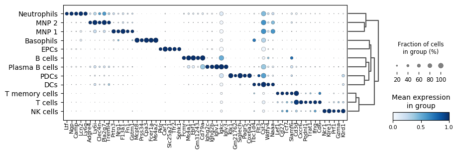

```python
dp = sc.pl.dotplot(adh, g, groupby='label', dendrogram=True, show=False,
        figsize=(10, 3), cmap='Blues', return_fig=True, standard_scale='var')
dp.style(largest_dot=50, cmap='Blues')
gfg = dp.get_axes()
ax = gfg['mainplot_ax'].axes
cax = gfg['color_legend_ax'].axes
xticks = ax.get_xticklabels(); yticks = ax.get_yticklabels()
ax.set_xticklabels(xticks, rotation=90, fontsize=8);
ax.tick_params(axis='x', which='both', pad=-1)
ax.tick_params(axis='y', which='both', pad=4, labelsize=10)
cax.tick_params(labelsize=8)
cax.set_title('Mean expression\nin group', fontsize=10);
sfig(ax.figure, fdm+'1C.dotplot_full_label_top_marker')
```

## Load MNP sub-population from WT + $\Delta$*STeE* STm infected mice

### Figure 1D: UMAP of MNP sub-populations showing leiden clustering

```python
fn = infd+'sam_monocyteSubset.210505.h5ad'
ad = sc.read_h5ad(fn)
```

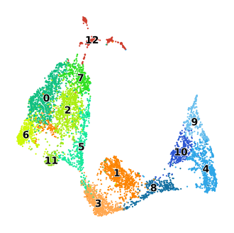

```python
fig, ax = plt.subplots(figsize=(4, 4))
sc.pl.umap(ad, color='leiden', legend_loc='on data', legend_fontsize=10,
        s=10, frameon=False, ax=ax, title='', legend_fontoutline=1)
sfig(fig, fdm+'1D.umap_mnp_leiden')
```

### SFigure 3: cell cycle phase of MNP population

leiden clusters 4, 8, 9, and 10 are likely proliferative progenitors of MNP.

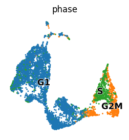

```python
X = ad.obsm['X_umap']
lb = ad.obs['phase'].values.astype(str)
tmpcmap = {'G1':'C0', 'G2M':'C1', 'S':'C2'}
c = [tmpcmap[x] for x in lb]
fig, ax = plt.subplots(figsize=(3, 3))
sc.pl.umap(ad, color='phase', ax=ax, legend_loc='on data',
           frameon=False, legend_fontsize=12, legend_fontoutline=True)
sfig(fig, fdm+'s3A.umap_mnp_phase')
```

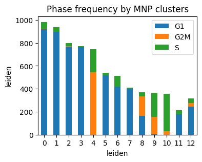

```python
D = ad.obs.groupby(['leiden', 'phase']).size().unstack()

fig, ax = plt.subplots(figsize=(4, 3))
D.plot(kind='bar', stacked=True, rot=0, ax=ax)
ax.legend(frameon=True);
ax.set_ylabel('cell counts');
ax.set_ylabel('leiden');
ax.set_title('Phase frequency by MNP clusters');
ax.grid(False)
sfig(fig, fdm+'s3B.bar_mnp_phase_frequency')
```

### Figure 1E: Dotplot of monocyte, macrophage, and GMP marker genes

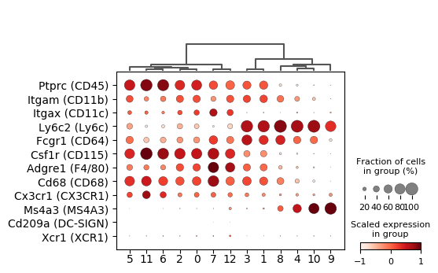

```python
gs = ['Ptprc', 'Itgam', 'Itgax', 'Ly6c2', 'Fcgr1', 'Csf1r', 'Adgre1', 'Cd68',
        'Cx3cr1', 'Ms4a3', 'Cd209a', 'Xcr1']

#### Take a subset using the immune cell marker genes
D = ad[:, gs].copy()
D.var['symbol'] = ['CD45', 'CD11b', 'CD11c', 'Ly6c', 'CD64', 'CD115', 'F4/80', 'CD68', 'CX3CR1', 'MS4A3', 'DC-SIGN', 'XCR1']
D.var['symbol'] = ['{:} ({:})'.format(x, y) for x,y in zip(D.var_names, D.var['symbol'])]
sc.pp.scale(D, max_value=2)

fig, ax = plt.subplots(figsize=(5, 4))
sc.tl.dendrogram(D, groupby='leiden', linkage_method='average', optimal_ordering=True)
dp = sc.pl.dotplot(D, var_names=D.var['symbol'].values, groupby='leiden',
                   swap_axes=True, dendrogram=True, gene_symbols='symbol',
                   ax=ax, show=False, return_fig=True, vmax=1, vmin=-1)
dp.style(largest_dot=125, cmap='Reds')
dp.legend(colorbar_title='Scaled expression\nin group')
gfg = dp.get_axes()
for i in gfg:
    gfg[i].tick_params(labelsize=8, rotation=0)
    gfg[i].set_title(gfg[i].get_title(), fontsize=8)
gfg['mainplot_ax'].tick_params(labelsize=10, axis='x', pad=0)
gfg['mainplot_ax'].tick_params(labelsize=10, axis='y')
sfig(fig, fdm+'1E.dotplot_mnp_macrophage_marker')
```

### Figure 1F: UMAP of MNP sub-population showing marker genes

```
Number of plots: 4
```

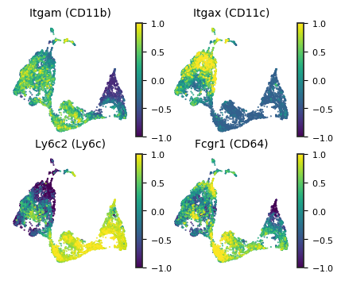

```python
gs = ['Itgam', 'Itgax', 'Ly6c2', 'Fcgr1']
D = ad[:, gs].copy()
D.var['symbol'] = ['CD11b', 'CD11c', 'Ly6c', 'CD64']
D.var['symbol'] = ['{:} ({:})'.format(x, y) for x,y in zip(D.var_names, D.var['symbol'])]
sc.pp.scale(D, max_value=2)

gfg = pl.umap(D, c=gs, adj=True, titles='symbol', s=.25, ncols=2, fontsize=10,
        figsize=(2 ,2), vmax=1, vmin=-1)

sfig(gfg.figure, fdm+'1F.umap_mnp_macrophage_marker')
```

### Figure 1G: CMH test on MNP cell states

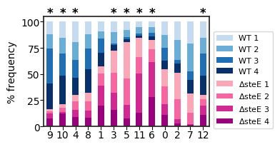

```python
#### We order the leiden clusters based on their cell type identities.
groups_order = ['9', '10', '4', '8', '1', '3', '5', '11', '6', '0', '2', '7', '12']
_cta_ = 'leiden'
obs = ad.obs[[_cta_, 'batch']].copy()

#### Normalize cell type counts to frequency
df_abundance = obs.groupby([_cta_, 'batch']).size().unstack().fillna(0)
df_norm = df_abundance.div(df_abundance.sum(axis=0), axis=1)*100
df_score = df_norm.divide(df_norm.max(axis=1), axis=0)*100
df = df_score.stack().reset_index()
df.columns = ['cluster', 'group', 'score']
df_percent = df_norm.stack().reset_index()
df_percent.columns = ['cluster', 'group', 'percent']

D = df_score.copy()
D.columns = [dt[x[0]] for x in D.columns]
D = pd.melt(D.reset_index(), id_vars=_cta_)
D.columns = ['cluster', 'group', 'frequency']

_cta_ = 'leiden'
obs = ad.obs[[_cta_, 'batch']].copy()
df_abundance = obs.groupby([_cta_, 'batch']).size().unstack().fillna(0)
Dpivot = df_abundance.div(df_abundance.sum(axis=0), axis=1)*100
Dpivot = Dpivot.div(Dpivot.sum(axis=1), axis=0)*100
Dpivot.columns = [dt[x[0]]+' '+x[1] for x in Dpivot.columns]
Dpivot = Dpivot.loc[groups_order].iloc[:, ::-1]
df_abundance.columns = [dt[x[0]]+' '+x[1] for x in df_abundance.columns]
df_abundance = df_abundance.loc[groups_order].iloc[:, ::-1]
Dmomac = Dpivot.copy()
dfMomac = df_abundance.copy()
top = mpl.cm.get_cmap('Blues', 128)
bottom = mpl.cm.get_cmap('RdPu', 128)
newcolors = np.vstack((bottom(np.linspace(0.35, 0.8, 4))[::-1], top(np.linspace(0.25, 1, 4))[::-1]))
newcmp = mpl.colors.ListedColormap(newcolors, name='RdPu')
res, ratio_difference = analysis.cmh_test(df_abundance.iloc[:, ::-1], K=4)
pthreshold = 0.05

fig, ax = plt.subplots(figsize=(3, 2))
gfg = Dpivot.plot(kind='bar', legend=True, ax=ax, rot=0, stacked=True, xlabel='', colormap=newcmp)
handles, labels = gfg.axes.get_legend_handles_labels()
gfg.axes.legend(handles[::-1], labels[::-1], fontsize=8, bbox_to_anchor=(1, .9))
ax.set_xlabel(''); ax.set_ylabel('% frequency', fontsize=10); ax.set_ylim(0, 105)
gfg.tick_params(labelsize=10, top=False, pad=0)
for i, index in enumerate(ratio_difference.index):
    if (ratio_difference.loc[index, 'fdr'] <= pthreshold) & (
            abs(ratio_difference.loc[index, 'log2_ratio']) >= 1):
        ax.text(i, 105, '*', ha='center', weight='bold', fontsize=12, zorder=10);
    ratio = np.round(ratio_difference.loc[index, 'log2_ratio'], 2)
sfig(fig, fdm+'1G.bar_mnp_relative_abundance.vertical')
```

### Figure 2A: Dotplot of marker genes in the MNP sub-population

Load the marker genes based on negative binomial differential test of all clusters found in the MNP sub-population.

```python
l2thres, pthres, min_expressed = 1, 0.05, 0.25
fns = glob(infd+'../marker/Monocyte_subset/negative_binomial/*.tsv.gz')
marker = {}
for fn in fns:
    cl = fn.split('/')[-1].split('_')[0]
    df = pd.read_csv(fn, sep='\t', index_col=0)
    marker[cl] = df[(df['log2-fold']>l2thres)*(df['adjusted-p']<pthres)*(df['expressed_a']>min_expressed)]

sc.tl.dendrogram(ad, groupby='leiden', linkage_method='average', optimal_ordering=True)
ad.uns['dendrogram_leiden'] = ad.uns["dendrogram_['leiden']"].copy()
groups_order = ad.uns["dendrogram_['leiden']"]['categories_ordered']
g = []
for x in groups_order:
    __ = marker[x]
    g.extend(__.loc[np.setdiff1d(__.index.values, g)].sort_values(
        'log2-fold', ascending=False).index.values[:5])
```

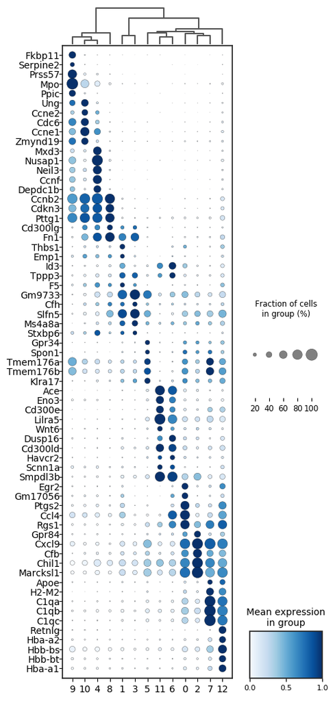

```python
dp = sc.pl.dotplot(ad, g, groupby='leiden', dendrogram=True, show=False, swap_axes=True,
        figsize=(5, 13), cmap='Blues', return_fig=True, standard_scale='var')
dp.style(largest_dot=150, cmap='Blues')
gfg = dp.get_axes()
ax = gfg['mainplot_ax'].axes
cax = gfg['color_legend_ax'].axes
xticks = ax.get_xticklabels(); yticks = ax.get_yticklabels()
ax.grid(False);
ax.set_xticklabels(xticks, rotation=0, fontsize=7);
ax.tick_params(axis='x', which='both', pad=4, labelsize=10)
ax.tick_params(axis='y', which='both', pad=-1, labelsize=10)
cax.tick_params(labelsize=8)
cax.set_title('Mean expression\nin group', fontsize=10);
sfig(ax.figure, fdm+'2A.dotplot_mnp_label_top_marker')
```

### Figure 2B: Macrophage-related functional module activity

```python
outDir = infd+'../marker/Macrophage_monocyte.Ccl4/GO/MSigDB/'

hmres = {}
for key in ['Ccl4+', 'Ccl4-', 'Spic+']:
    hmres[key] = pd.read_csv(outDir+'{:}_HallmarkUp.tsv.gz'.format(key), sep='\t', index_col=0)
```

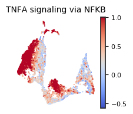

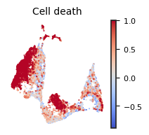

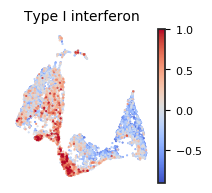

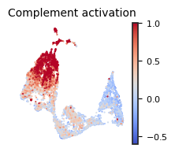

```python
#### Complement gene sets
complement_genes = ['C1qa', 'C1qc', 'C3', 'Ccl5', 'Cfb', 'Ctsd', 'Ctsl', 'Ehd1', 'Gca', 'Hspa5', 'Kynu', 'Mmp14', 'Pla2g4a', 'Usp14']
#### Type I inteferon gene sets
typeI_genes = ['Gm26825', 'Txnip', 'F630028O10Rik', 'Ifit1', 'Tmcc1', 'Oasl2']
#### Cell death gene sets
cell_death_genes = hmres['Ccl4+'].loc['HALLMARK_APOPTOSIS', 'intersect_gene'].split(',')
#### TNF-a NFKB signaling pathway
tnfa_nfkb_genes = np.setdiff1d(hmres['Ccl4+'].loc['HALLMARK_TNFA_SIGNALING_VIA_NFKB', 'intersect_gene'].split(','), cell_death_genes)

#### We use scanpy.tl.score_genes to evaluate the expression level of these gene sets relative
#### to randomly selected gene sets of equal size
sc.tl.score_genes(ad, tnfa_nfkb_genes, score_name='TNFA signaling via NFKB', random_state=123)
sc.tl.score_genes(ad, cell_death_genes, score_name='Cell death', random_state=123)
sc.tl.score_genes(ad, typeI_genes, score_name='Type I interferon', random_state=123)
sc.tl.score_genes(ad, complement_genes, score_name='Complement activation', random_state=123)

gfg = pl.umap(ad, c='TNFA signaling via NFKB', cmap='coolwarm', s=.25, vmax=1,
        figsize=(2, 2), fontsize=10);
sfig(gfg.figure, fdm+'2B.umap_mnp_tnfa_signaling_via_nfkb_score')
gfg = pl.umap(ad, c='Cell death', cmap='coolwarm', s=.25, vmax=1,
        figsize=(2, 2), fontsize=10);
sfig(gfg.figure, fdm+'2B.umap_mnp_cell_death_score')
gfg = pl.umap(ad, c='Type I interferon', s=.25, cmap='coolwarm', vmax=1,
        figsize=(2, 2), fontsize=10);
sfig(gfg.figure, fdm+'2B.umap_mnp_type_I_interferon_score')
gfg = pl.umap(ad, c='Complement activation', s=.25, cmap='coolwarm', vmax=1,
        figsize=(2, 2), fontsize=10);
sfig(gfg.figure, fdm+'2B.umap_mnp_complement_score')
```

### Figure 2C: Dotplot of red-pulp macrophages (RPMs) marker genes

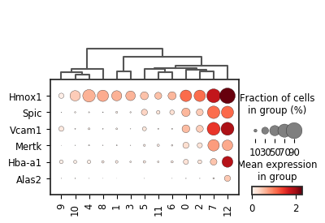

```python
ad.obs['label'] = ['MoMac '+x for x in ad.obs['leiden'].values]
ad.obs['label'] = ad.obs['label'].astype('category')
sc.tl.dendrogram(ad, groupby='label', linkage_method='average', optimal_ordering=True)
sc.tl.dendrogram(ad, groupby='leiden', linkage_method='average', optimal_ordering=True)
gs = ['Hmox1', 'Spic', 'Vcam1', 'Mertk', 'Hba-a1', 'Alas2']
D = ad[:, gs].copy()

fig, ax = plt.subplots(figsize=(4, 3))
ax.tick_params(axis='x', rotation=0);
sc.pl.dotplot(D, var_names=D.var_names, groupby='leiden', swap_axes=True,
        dendrogram=True, ax=ax, show=False, var_group_rotation=0);
sfig(fig, fdm+'2C.dotplot_mnp_RPM_marker.leiden')
```

### Figure 2D: UMAP of MNP sub-population showing RPM marker gene score

```
reading existing /jupyter/src/python/variables/../../../data/h5ad/../external/processed_PanglaoDB_markers_24_Jan_2020.tsv.gz
```

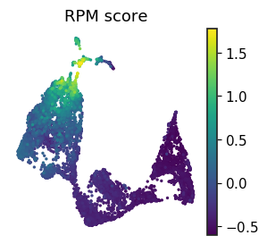

```python
panglao_marker = analysis.load_panglaoDB(ad)
rpm_marker = panglao_marker[panglao_marker['cell type'].isin(['Red pulp macrophages'])]['GeneSymbol'].values
sc.tl.score_genes(ad, rpm_marker, score_name='RPM score')

gfg = pl.umap(ad, c='RPM score', s=2, adj=True)
sfig(gfg.figure, fdm+'2D.umap_mnp_RPM_score_averaged.monocyte.pdf')
```

### Figure 2G: RNA velocity stream plot

```
computing velocity embedding
    finished (0:00:02) --> added
    'velocity_umap', embedded velocity vectors (adata.obsm)
```

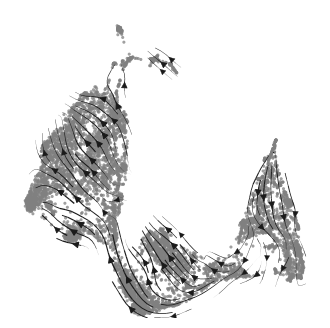

```python
admv = sc.read_h5ad(infd+'sam_monocyte_velocyto.210505.h5ad')
admv.uns['neighbors'] = {}
admv.uns['neighbors']['distances'] = ad.obsp['distances']
admv.uns['neighbors']['connectivities'] = ad.obsp['connectivities']

axs = scv.pl.velocity_embedding_stream(admv, show=False, alpha=0.75,
                                       title='', figsize=(4, 4), color_map='coolwarm',
                                       size=20, fontsize=10, density=0.75,
                                       linewidth=0.5, colorbar=False)
axs.grid(0)
axs.figure.savefig(fdm+'2G.mnp_rna_velocity_stream_latent_time.png',
                   bbox_inches='tight', transparent=True, dpi=500)
```

## Load monocyte-macrophage (MoMac) sub-population from WT + $\Delta$*STeE* STm infected mice

### Figure 3A: UMAP in MoMac showing leiden clusters

```python
ad = sc.read_h5ad(infd+'sam_macrophageSubset_AB.210919.h5ad')
```

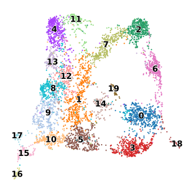

```python
fig, ax = plt.subplots(figsize=(4, 4))
sc.pl.umap(ad, color='sub_leiden', legend_loc='on data', legend_fontsize=10,
        s=10, frameon=False, ax=ax, title='', legend_fontoutline=1)
sfig(fig, fdm+'3A.umap_momac_leiden')
```

### Figure 3B: Dotplot of marker genes in MoMac sub-population

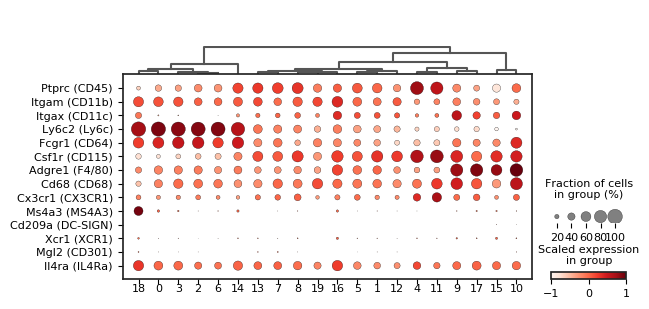

```python
gs = ['Ptprc', 'Itgam', 'Itgax', 'Ly6c2', 'Fcgr1', 'Csf1r', 'Adgre1', 'Cd68',
        'Cx3cr1', 'Ms4a3', 'Cd209a', 'Xcr1', 'Mgl2', 'Il4ra']
D = ad[:, gs].copy()
D.X = D.X.A
D.var['symbol'] = ['CD45', 'CD11b', 'CD11c', 'Ly6c', 'CD64', 'CD115', 'F4/80', 'CD68', 'CX3CR1', 'MS4A3', 'DC-SIGN', 'XCR1', 'CD301', 'IL4Ra']
D.var['symbol'] = ['{:} ({:})'.format(x, y) for x,y in zip(D.var_names, D.var['symbol'])]
sc.tl.dendrogram(D, groupby='sub_leiden', linkage_method='complete', optimal_ordering=True)
sc.pp.scale(D, max_value=2)

fig, ax = plt.subplots(figsize=(6.5, 3.5))
dp = sc.pl.dotplot(D, var_names=D.var['symbol'].values, groupby='sub_leiden', swap_axes=True, dendrogram=True, gene_symbols='symbol', ax=ax, show=False, return_fig=True, vmax=1, vmin=-1)
dp.style(largest_dot=110, cmap='Reds')
dp.legend(colorbar_title='Scaled expression\nin group')
gfg = dp.get_axes()
for i in gfg:
    gfg[i].tick_params(labelsize=8)
    gfg[i].set_title(gfg[i].get_title(), fontsize=8)
gfg['mainplot_ax'].tick_params(labelsize=8, axis='x', pad=0, rotation=0)
gfg['mainplot_ax'].tick_params(labelsize=8, axis='y')
sfig(fig, fdm+'3B.dotplot_momac_marker.momacsub_AB')
```

### Figure 3C: UMAP of MoMac showing cell type annotations

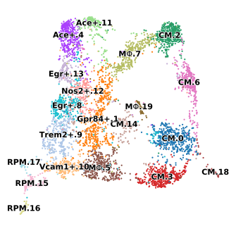

```python
fig, ax = plt.subplots(figsize=(4, 4))
sc.pl.umap(ad, color='cell_type', legend_loc='on data', legend_fontsize=8,
        s=10, frameon=False, ax=ax, title='', legend_fontoutline=1)
sfig(fig, fdm+'3C.umap_momac_cell_type')
```

### Differential gene expression and pathway analysis

`analysis.export_marker` provides a function to export the results of two kinds of differential gene expression tests.

#### Differential gene marker gene discovery

```python
#### Marker genes analysis for MoMac sub-population

outDir = out+'marker/momacsub_AB.cell_type/'
analysis.export_marker(ad, outDir, groupby='cell_type')
```

```
Ace+.11
Ace+.4
CM.0
CM.14
CM.18
CM.2
CM.3
CM.6
Egr+.13
Egr+.8
Gpr84+.1
M$\Phi$.19
M$\Phi$.5
M$\Phi$.7
Nos2+.12
RPM.15
RPM.16
RPM.17
Trem2+.9
Vcam1+.10
Computing params...
Computing DE for cluster Ace+.11...
```

```
Computing 16769 exact tests and 226 asymptotic tests.
```

```
Computing DE for cluster Ace+.4...
```

```
Computing 16589 exact tests and 406 asymptotic tests.
```

```
Computing DE for cluster CM.0...
```

```
Computing 16021 exact tests and 974 asymptotic tests.
```

```
Computing DE for cluster CM.14...
```

```
Computing 16591 exact tests and 404 asymptotic tests.
```

```
Computing DE for cluster CM.18...
```

```
Computing 16663 exact tests and 332 asymptotic tests.
```

```
Computing DE for cluster CM.2...
```

```
Computing 16464 exact tests and 531 asymptotic tests.
```

```
Computing DE for cluster CM.3...
```

```
Computing 16219 exact tests and 776 asymptotic tests.
```

```
Computing DE for cluster CM.6...
```

```
Computing 16557 exact tests and 438 asymptotic tests.
```

```
Computing DE for cluster Egr+.13...
```

```
Computing 16772 exact tests and 223 asymptotic tests.
```

```
Computing DE for cluster Egr+.8...
```

```
Computing 16272 exact tests and 723 asymptotic tests.
```

```
Computing DE for cluster Gpr84+.1...
```

```
Computing 16264 exact tests and 731 asymptotic tests.
```

```
Computing DE for cluster M$\Phi$.19...
```

```
Computing 16882 exact tests and 113 asymptotic tests.
```

```
Computing DE for cluster M$\Phi$.5...
```

```
Computing 16373 exact tests and 622 asymptotic tests.
```

```
Computing DE for cluster M$\Phi$.7...
```

```
Computing 16615 exact tests and 380 asymptotic tests.
```

```
Computing DE for cluster Nos2+.12...
```

```
Computing 16732 exact tests and 263 asymptotic tests.
```

```
Computing DE for cluster RPM.15...
```

```
Computing 16673 exact tests and 322 asymptotic tests.
```

```
Computing DE for cluster RPM.16...
```

```
Computing 16687 exact tests and 308 asymptotic tests.
```

```
Computing DE for cluster RPM.17...
```

```
Computing 16780 exact tests and 215 asymptotic tests.
```

```
Computing DE for cluster Trem2+.9...
```

```
Computing 16128 exact tests and 867 asymptotic tests.
```

```
Computing DE for cluster Vcam1+.10...
```

```
Computing 16565 exact tests and 430 asymptotic tests.
```

```
Exported marker genes!
```

Load differential marker genes:

- specific marker results
- negative binomial results

```python
specific_res = {x.split('/')[-1].split('_')[1]:pd.read_csv(x, index_col=0, sep='\t')
          for x in glob(outDir+'specific_marker/*.tsv.gz')}
nb_res = {x.split('/')[-1].split('_')[0]:pd.read_csv(x, index_col=0, sep='\t')
          for x in glob(outDir+'negative_binomial/*.tsv.gz')}
```

```python
specific_res['Ace+.4'].head()
```

|  | fold | max1_mean | max2_mean | p | max1 | max2 | log2-fold | abs-log2-fold | adjusted-p |
| --- | --- | --- | --- | --- | --- | --- | --- | --- | --- |
| Nr4a1 | 1.513835 | 2.771761 | 1.830954 | 2.775471e-32 | Ace+.4 | Egr+.8 | 0.598208 | 0.598208 | 8.618670e-28 |
| Stap1 | 2.332028 | 1.735030 | 0.744001 | 2.185951e-22 | Ace+.4 | Ace+.11 | 1.221585 | 1.221585 | 7.542261e-19 |
| Cebpb | 1.072381 | 4.934650 | 4.601583 | 1.516945e-09 | Ace+.4 | CM.6 | 0.100818 | 0.100818 | 1.121564e-06 |
| Btg1 | 1.090296 | 4.371661 | 4.009610 | 1.993856e-09 | Ace+.4 | Egr+.13 | 0.124719 | 0.124719 | 1.439888e-06 |
| Itga4 | 1.237487 | 2.333878 | 1.885982 | 1.903403e-08 | Ace+.4 | Ace+.11 | 0.307413 | 0.307413 | 1.019076e-05 |

```python
nb_res['Ace+.4'].head()
```

|  | tested | sum_a | sum_b | common_mean | common_dispersion | norm_mean_a | norm_mean_b | expressed_a | expressed_b | p | adjusted-p | log2-fold |
| --- | --- | --- | --- | --- | --- | --- | --- | --- | --- | --- | --- | --- |
| Ace | True | 947.0 | 1445.0 | 0.587797 | 39.386549 | 3.416751 | 0.229535 | 0.762125 | 0.122671 | 2.852992e-26 | 4.848661e-22 | 3.891394 |
| Dusp16 | True | 450.0 | 880.0 | 0.309026 | 41.812842 | 1.623588 | 0.139786 | 0.535797 | 0.125446 | 4.168657e-19 | 2.693723e-15 | 3.534488 |
| Eno3 | True | 505.0 | 1002.0 | 0.337625 | 41.662582 | 1.822026 | 0.159166 | 0.491917 | 0.110186 | 4.755027e-19 | 2.693723e-15 | 3.513390 |
| Adrb1 | True | 117.0 | 174.0 | 0.065792 | 53.492924 | 0.422133 | 0.027640 | 0.203233 | 0.024772 | 7.868928e-17 | 3.343311e-13 | 3.931935 |
| Scnn1a | True | 233.0 | 470.0 | 0.162203 | 44.275512 | 0.840658 | 0.074659 | 0.321016 | 0.073127 | 1.055435e-16 | 3.587425e-13 | 3.491284 |

#### Gene set over-representation analysis (GSOA) test results

`analysis.run_GSOA` provides a wrapper function to compute the GSOA analysis. This requires an input list of paths containing the negative binomial test results, the output directory, and a list of the cluster labels (have to match the input file paths).

```python
fns = glob(infd+'../marker/momacsub_AB.cell_type/negative_binomial/*.tsv.gz')
outDir = out+'marker/momacsub_AB.cell_type/GO/MSigDB/'
groups = np.unique(ad.obs['cell_type'])

gsoa = analysis.run_GSOA(fns, outDir, groups)
```

```python
gsoa['Ace+.4'].keys()
```

```
dict_keys(['ReactomeUp', 'TargetTranscriptionUp', 'HallmarkUp', 'TargetTranscriptionDown', 'WikipathwaysDown', 'PID_Down', 'ImmuneSignatureDown', 'BioCartaDown', 'ReactomeDown', 'PID_Up', 'KEGG_MetabolismDown', 'KEGG_MetabolismUp', 'ImmuneSignatureUp', 'BioCartaUp', 'HallmarkDown', 'WikipathwaysUp']…
```

```python
gsoa['Ace+.4']['HallmarkUp'].head()
```

|  | pathway | intersect_size | query_size | set_size | intersect_gene | pval | padj |
| --- | --- | --- | --- | --- | --- | --- | --- |
| HALLMARK_TNFA_SIGNALING_VIA_NFKB | HALLMARK_TNFA_SIGNALING_VIA_NFKB | 14 | 78 | 199 | Bcl6,Cd83,Dusp2,Dusp5,Ets2,Il1b,Map3k8,Nr4a1,P... | 8.864001e-17 | 8.864001e-17 |
| HALLMARK_IL2_STAT5_SIGNALING | HALLMARK_IL2_STAT5_SIGNALING | 11 | 78 | 198 | Bcl2,Ccnd2,Cd83,Eno3,Itgav,Ltb,Map3k8,Nfkbiz,T... | 2.870463e-12 | 5.740925e-12 |
| HALLMARK_KRAS_SIGNALING_UP | HALLMARK_KRAS_SIGNALING_UP | 7 | 78 | 199 | Ace,Ccnd2,Cxcr4,Il1b,Pecam1,Traf1,Trib1 | 7.180599e-07 | 2.154180e-06 |
| HALLMARK_IL6_JAK_STAT3_SIGNALING | HALLMARK_IL6_JAK_STAT3_SIGNALING | 5 | 78 | 86 | Cd36,Cd9,Il1b,Ltb,Map3k8 | 2.608011e-06 | 1.043204e-05 |
| HALLMARK_HYPOXIA | HALLMARK_HYPOXIA | 6 | 78 | 199 | Bcl2,Cdkn1b,Cxcr4,Eno3,Gcnt2,Tgm2 | 1.124096e-05 | 5.620482e-05 |

```python
gsoa['Ace+.4']['HallmarkDown'].head()
```

|  | pathway | intersect_size | query_size | set_size | intersect_gene | pval | padj |
| --- | --- | --- | --- | --- | --- | --- | --- |
| HALLMARK_COMPLEMENT | HALLMARK_COMPLEMENT | 2 | 11 | 199 | C1qa,C1qc | 0.002163 | 0.002163 |
| HALLMARK_IL6_JAK_STAT3_SIGNALING | HALLMARK_IL6_JAK_STAT3_SIGNALING | 1 | 11 | 86 | Ccr1 | 0.030050 | 0.060101 |
| HALLMARK_COAGULATION | HALLMARK_COAGULATION | 1 | 11 | 137 | C1qa | 0.047481 | 0.142443 |
| HALLMARK_TNFA_SIGNALING_VIA_NFKB | HALLMARK_TNFA_SIGNALING_VIA_NFKB | 1 | 11 | 199 | Sdc4 | 0.068287 | 0.273149 |
| HALLMARK_HYPOXIA | HALLMARK_HYPOXIA | 1 | 11 | 199 | Sdc4 | 0.068287 | 0.341436 |

GSEA was also computed for some of the datasets following default parameter settings.

All differential gene expression, GO term, GSEA, and other analyses are accessible on [the Google Drive folder](https://drive.google.com/drive/folders/1ohx-A5gmWS42yG77ee6h7KLyaY4CINQV?usp=share_link) at: **google_drive_public/marker/**

### Figure 3E: Dotplot of marker genes in MoMac sub-population

Load the marker genes based on negative binomial differential test of all clusters found in MoMac sub-population.

```python
l2thres, pthres, min_expressed = 1, 0.05, 0.1
fns = glob(infd+'../marker/momacsub_AB.cell_type/negative_binomial/*.tsv.gz')
marker = {}
for fn in fns:
    cl = fn.split('/')[-1].split('_')[0]
    df = pd.read_csv(fn, sep='\t', index_col=0)
    marker[cl] = df[(df['log2-fold']>l2thres)*(df['adjusted-p']<pthres)*(df['expressed_a']>min_expressed)]
```

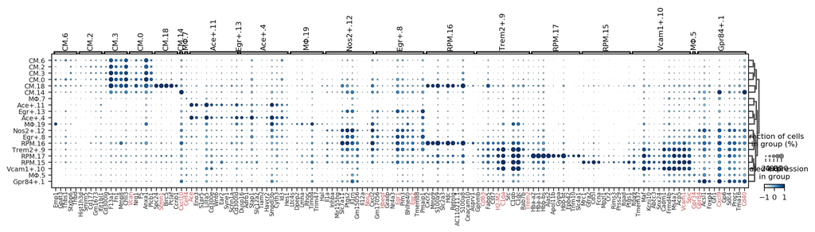

```python
lbmap = dict(zip(ad.obs['sub_leiden'], ad.obs['cell_type']))
sc.tl.dendrogram(ad, groupby='cell_type', linkage_method='average', optimal_ordering=True)
grouporder = ad.uns["dendrogram_['cell_type']"]['categories_ordered']

exclude, added_genes = [], []
gs = {}
for ct in grouporder:
    if ct not in exclude:
        if 'CM.' in ct:
            ngenes = 5
        else:
            ngenes = 10
        g = np.setdiff1d(marker[ct].index, added_genes)
        to_add = marker[ct].loc[g].sort_values('adjusted-p').index.values[:ngenes]
        gs[ct] = to_add
        added_genes.extend(to_add)
gs['Trem2+.9'] = np.concatenate([gs['Trem2+.9'], ['Trem2']])
gs['Vcam1+.10'] = np.concatenate([gs['Vcam1+.10'], ['Vcam1', 'Spic']])

# A list of genes to annotate on the tick labels
anng = ['Ace', 'Nos2', 'Trem2', 'Vcam1', 'Egr1', 'Egr2', 'Hbegf', 'Celf4', 'Gpr34', 'Spic', 'Gpr84', 'Ms4a3', 'Stmn1', 'Top2a', 'Vcan', 'Sell', 'Cx3cr1', 'Cd63', 'H2-M2', 'C1qa', 'Rgs1', 'Cxcl10', 'Cd40', 'Cxcl9']

sub = ad.copy()
sc.pp.scale(sub, max_value=2)

sc.set_figure_params(fontsize=8, dpi=100, vector_friendly=True)
fig, ax = plt.subplots(figsize=(14, 3))
dp = sc.pl.dotplot(sub, var_names=gs, groupby='cell_type', dendrogram=True,
        ax=ax, show=False, return_fig=True, vmax=1, vmin=-1, var_group_rotation=90)
dp.style(largest_dot=25, cmap='Blues')
dp.legend(colorbar_title='Scaled expression\nin group')
gfg = dp.get_axes()
ax = gfg['mainplot_ax']
xtl = ax.get_xticklabels()
fig = ax.figure
for i in gfg:
    gfg[i].tick_params(labelsize=8)
    gfg[i].set_title(gfg[i].get_title(), fontsize=8)
ax.tick_params(labelsize=6, axis='x', pad=0, rotation=90)
ax.tick_params(labelsize=7, axis='y')
newxtl = [x.set_color('r') if x.get_text() in anng else '' for x in xtl]
sfig(fig, fdm+'3E.dotplot_momac_marker_AB')
```

### Figure 3F: CMH test on MoMac cell states

```python
_cta_ = 'cell_type'
total = ad.obs[[_cta_, 'batch', 'treatment']].copy().astype(str)
df_abundance = total.groupby([_cta_, 'batch']).size().unstack().fillna(0)
Dpivot = df_abundance.div(df_abundance.sum(axis=0), axis=1)*100
Dpivot = Dpivot.div(Dpivot.sum(axis=1), axis=0)*100
Dpivot.columns = [dt[x[0]] for x in Dpivot.columns]
D = Dpivot.unstack().reset_index()
D.columns = ['treatment', 'cluster', '% frequency']

mean = D.groupby(['treatment', 'cluster']).mean()
Dplot = mean.unstack()['% frequency'].T
std = D.groupby(['treatment', 'cluster']).std()
Dplotstd = std.unstack()['% frequency'].T
groups_order = list((mean.loc[dt['B']] - mean.loc[dt['A']]).sort_values('% frequency').index)[::-1]
corder = [dt[x] for x in ['B', 'A', 'C', 'T']]

obs = ad.obs[[_cta_, 'batch']].copy()
df_abundance = obs.groupby([_cta_, 'batch']).size().unstack().fillna(0)
Dpivot = df_abundance.div(df_abundance.sum(axis=0), axis=1)*100
Dpivot = Dpivot.div(Dpivot.sum(axis=1), axis=0)*100
Dpivot.columns = [dt[x[0]]+' '+x[1] for x in Dpivot.columns]
Dpivot = Dpivot.loc[groups_order].iloc[:, ::-1]
df_abundance.columns = [dt[x[0]]+' '+x[1] for x in df_abundance.columns]
df_abundance = df_abundance.loc[groups_order].iloc[:, ::-1]
Dmomac = Dpivot.copy()
dfMomac = df_abundance.copy()
top = mpl.cm.get_cmap('Blues', 128)
bottom = mpl.cm.get_cmap('RdPu', 128)
newcolors = np.vstack((bottom(np.linspace(0.35, 0.8, 4))[::-1], top(np.linspace(0.25, 1, 4))[::-1]))
newcmp = mpl.colors.ListedColormap(newcolors, name='RdPu')
res, ratio_difference = analysis.cmh_test(df_abundance.iloc[:, ::-1], K=4)
pthreshold = 0.05
```

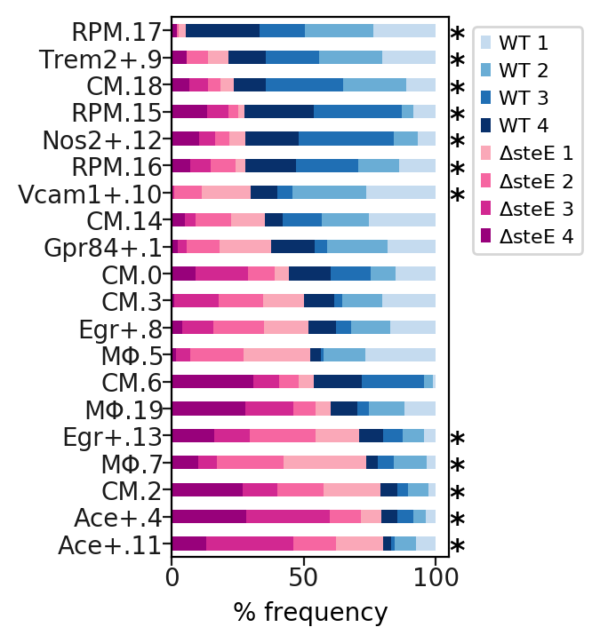

```python
fig, ax = plt.subplots(figsize=(2, 4))
gfg = Dpivot.plot(kind='barh', legend=True, ax=ax, rot=0, stacked=True, xlabel='', colormap=newcmp)
handles, labels = gfg.axes.get_legend_handles_labels()
gfg.axes.legend(handles[::-1], labels[::-1], fontsize=8, bbox_to_anchor=(1.05, 1))
ax.set_ylabel(''); ax.set_xlabel('% frequency', fontsize=10); ax.set_xlim(0, 105)
ax.grid(False);
gfg.tick_params(labelsize=10, top=False, pad=0)
for i, index in enumerate(ratio_difference.index):
    if (ratio_difference.loc[index, 'fdr'] <= pthreshold) & (
            abs(ratio_difference.loc[index, 'log2_ratio']) >= 1):
        ax.text(105, i-0.3, '*', va='center', weight='bold', fontsize=12, zorder=10);
    ratio = np.round(ratio_difference.loc[index, 'log2_ratio'], 2)
sfig(fig, fdm+'3F.bar_momac_AB_relative_abundance.vertical')
```

### Figure 3G: Volcano plot of differential genes in selected MoMac cell types from WT and $\Delta$*STeE* infected mice

```python
outDir = infd+'../marker/selected_momac_AB.AvsB/negative_binomial/'
marker = analysis.load_marker_gene(outDir)
l2thres, pthres, min_expressed = .5, 0.05, 0.1
for cl in marker:
    df = marker[cl]
dfscore = marker['A'].copy()
dfscore['score'] = -np.log10(dfscore['adjusted-p']) * dfscore['log2-fold']
anng = ['Ace', 'Nos2', 'S1pr5', 'Eno3', 'Id3', 'Havcr2', 'Cd300ld', 'Serpinb2', 'Marco', 'Trem2', 'Saa3', 'Prtn3', 'Gpnmb', 'Ccl8', 'Apoe', 'Stab1', 'Vcam1', 'Egr1', 'Cxcl9']
```

```
findfont: Font family ['Arial'] not found. Falling back to DejaVu Sans.
findfont: Font family ['Arial'] not found. Falling back to DejaVu Sans.
```

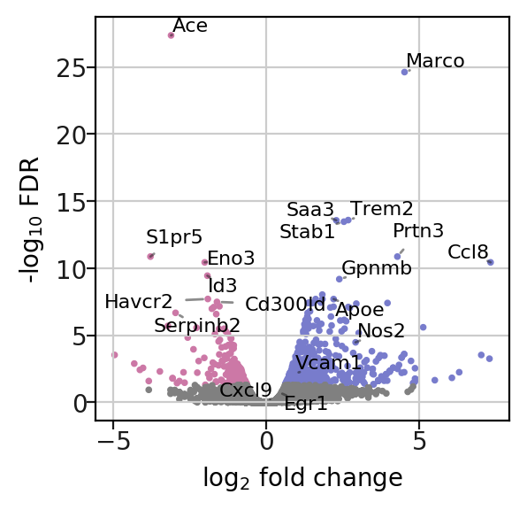

```python
fig, ax = plt.subplots(figsize=(3, 3))
pl.volcano(dfscore, ax=ax, annotate=anng, lfc_thr=0.5, axlabelfontsize=10,
        axtickfontsize=10, gfont=8, axylabel=r'-log$_{10}$ FDR', axxlabel=r'log$_2$ fold change',
        color=(dtcmap[dt['A']], dtcmap[dt['B']]))
ax.tick_params(labelsize=10, pad=0);
sfig(fig, fdm+'3G.volcano_selected_momac.A_vs_B');
```

```python
threshold = 3
pthreshold = .1

outDir = infd+'../marker/selected_momac_AB.AvsB/GO/MSigDB/'
goa = analysis.load_GSOA(outDir)
excluded_pathways = np.setdiff1d(list(goa['A'].keys()), ['HallmarkUp'])

combined_A = analysis.get_combined_goa(goa['A'], excluded_pathways, intersect_threshold=threshold, pthreshold=pthreshold)
combined_A['treatment'] = dt['A']
combined_B = analysis.get_combined_goa(goa['B'], excluded_pathways, intersect_threshold=threshold, pthreshold=pthreshold)
combined_B['treatment'] = dt['B']

combined = pd.concat([combined_A, combined_B]).sort_values('-log10_fdr', ascending=False)
Dplot = combined.pivot('pathway', 'treatment', '-log10_fdr').fillna(0)
Dplot = Dplot.sort_values('WT')[::-1]
Dplot.index = [' '.join(x.split('_')[1:]) for x in Dplot.index]
```

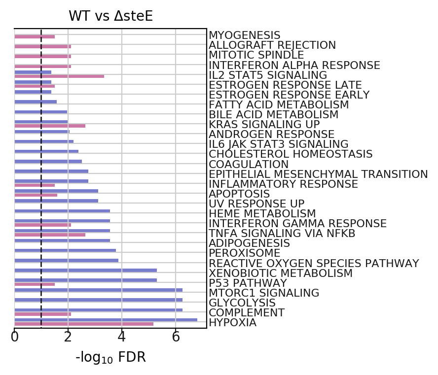

```python
fig, ax = plt.subplots(figsize=(2.5, 4))
Dplot.plot(kind='barh', ax=ax, color=[dtcmap[dt['B']], dtcmap[dt['A']]], width=.75, legend=False, lw=0.5)
ax.axvline(1, ax.get_ylim()[0], ax.get_ylim()[1], color='k', ls='--', alpha=0.75, lw=1);
ax.tick_params(axis='y', labelsize=7)
ax.set_ylabel('')
ax.yaxis.tick_right()
ax.spines['left'].set_visible(False)
ax.spines['right'].set_visible(True)
ax.set_title(r'{:} vs {:}'.format(dt['A'], dt['B']), fontsize=10);
ax.set_xlabel('-log$_{10}$ FDR', fontsize=10, rotation=0);
ax.axvline(1, ax.get_ylim()[0], ax.get_ylim()[1], color='k', ls='--', lw=1, alpha=0.75);
ax.tick_params(labelsize=8, axis='y', right=False, pad=-2);
ax.tick_params(labelsize=10, axis='x', pad=-2);
sfig(fig, fdm+'3H.barh_GSOA_AB.selected_momac_AB.KEGG.A_vs_B')
```

## Load the integrated monocyte-macrophage (MoMac) sub-population datasets from WT, $\Delta$*STeE*, WT + control IgG antibody, and WT + anti-TNF$\alpha$ mice.

```python
wfn = infd+'ABCT_SAM_momac.220828_review.h5ad'
ad = sc.read_h5ad(wfn)
```

### Figure 6A: Violin plot of interleukin expression in Ace$^+$ and Nos2$^+$ macrophages.

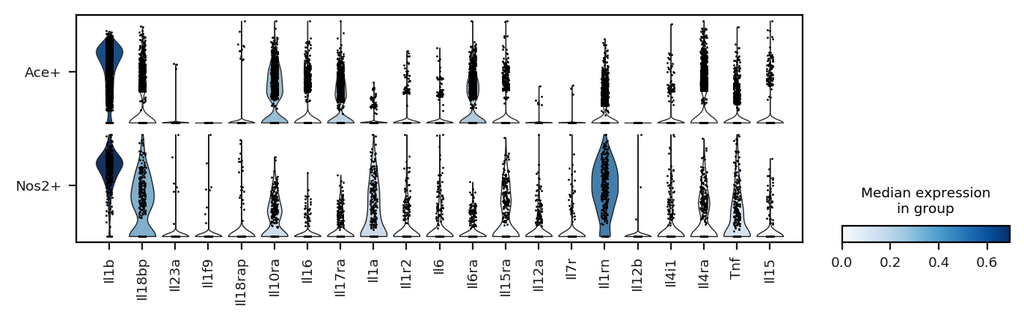

```python
gs = ['Il1b', 'Il18bp', 'Il23a', 'Il1f9', 'Il18rap', 'Il10ra', 'Il16', 'Il17ra',
      'Il1a', 'Il1r2', 'Il6', 'Il6ra', 'Il15ra', 'Il12a', 'Il7r', 'Il1rn', 'Il12b',
      'Il4i1', 'Il4ra', 'Tnf', 'Il15']

subset = ad[ad.obs['cell_type'].str.contains('Ace+') | ad.obs['cell_type'].str.contains('Nos2+')]
subset.obs['cell_type_label'] = [x.split('.')[0] for x in subset.obs['cell_type']]

fig = sc.pl.stacked_violin(subset, var_names=gs, groupby='cell_type_label',
                           figsize=(8, 2), show=False, size=0.05,
                           rotation=90, standard_scale='var', return_fig=True)
fig.style(y_padding=0, linewidth=0.5, jitter=True, stripplot=True);
ax = fig.get_axes()['mainplot_ax'];
xticklabels = ax.get_xticklabels()
ax.set_xticklabels(xticklabels, va='top');
fig = ax.get_figure()
sfig(fig, fdm+'6A.stacked_violinplot.AB.Ace_vs_Nos2.IL')
```

### Figure 6B: UMAP of integrated MoMac showing cell type annotations

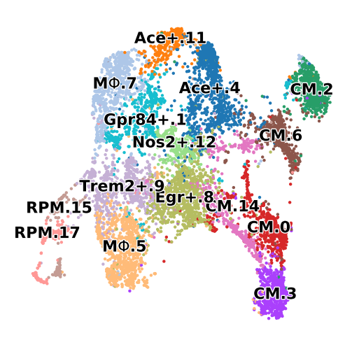

```python
fig, ax = plt.subplots(figsize=(3, 3))
sc.pl.umap(ad, color='fig3_cell_type', s=10, legend_loc='on data',
           legend_fontsize=8, ax=ax, legend_fontoutline=True,
           title='', show=False, frameon=False)
ax.set_xlabel(''); ax.set_ylabel('');
sfig(fig, fdm+'6B.umap_momacsub_celltype_ABCT.SAM.fixed')
```

### Figure 6C: UMAP of integrated datasets showing expression of macrophage markers

```
Number of plots: 6
```

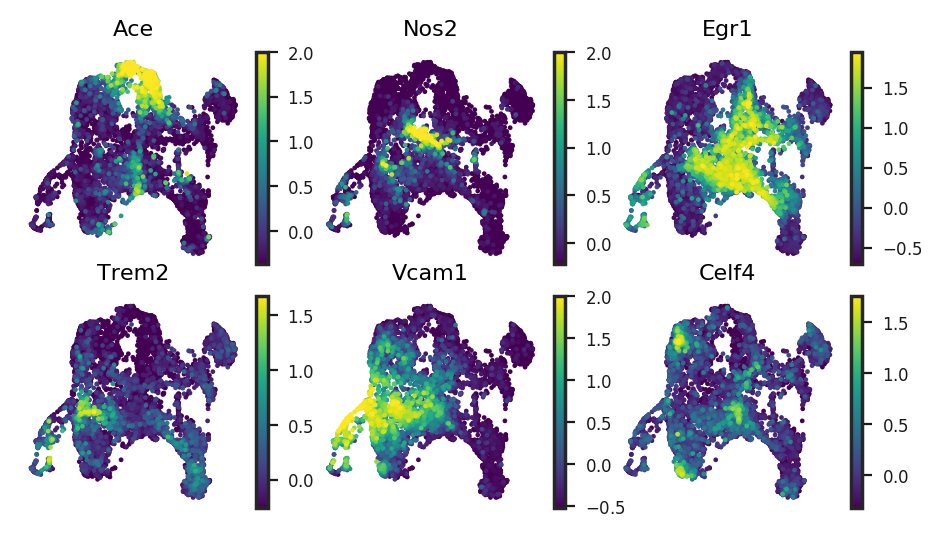

```python
sub = ad.copy()
sc.pp.scale(sub, max_value=2)

gs = ['Ace', 'Nos2', 'Egr1', 'Trem2', 'Vcam1', 'Celf4']
gfg = pl.umap(sub, c=gs, s=0.5, ncols=3, adj=True, figsize=(1.5, 1.5), fontsize=8);
sfig(gfg.figure, fdm+'6C.umap_momacsub_ABCT_marker_genes.SAM')
```

### Figure 6D: CMH test on MoMac cell states from integrated datasets

WT (A), $\Delta$*STeE* (B) infected mice

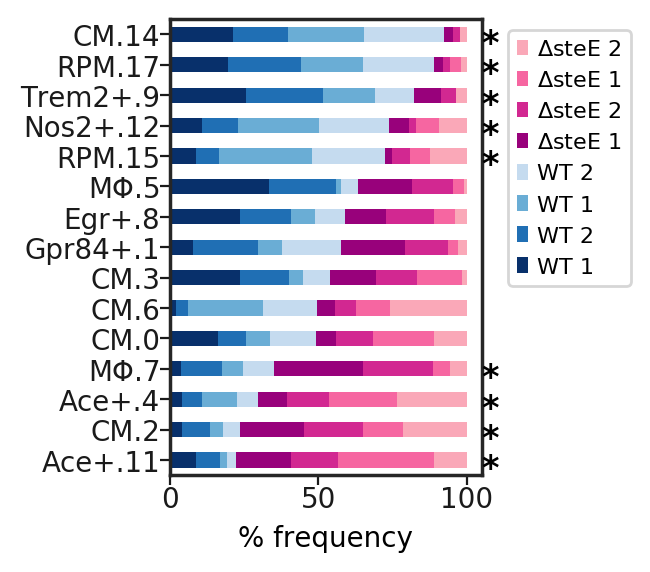

```python
admac = ad[ad.obs['treatment'].isin(['A', 'B'])]

_cta_ = 'fig3_cell_type'
groups_order = admac.obs[_cta_].unique()
total = admac[admac.obs[_cta_].isin(groups_order)].obs[[_cta_, 'batch',
    'treatment']].copy().astype(str)
df_abundance = total.groupby([_cta_, 'batch']).size().unstack().fillna(0)
Dpivot = df_abundance.div(df_abundance.sum(axis=0), axis=1)*100
Dpivot = Dpivot.div(Dpivot.sum(axis=1), axis=0)*100
Dpivot.columns = [dt[x[0]] for x in Dpivot.columns]
D = Dpivot.unstack().reset_index()
D.columns = ['treatment', 'cluster', '% frequency']

mean = D.groupby(['treatment', 'cluster']).mean()
Dplot = mean.unstack()['% frequency'].T
std = D.groupby(['treatment', 'cluster']).std()
Dplotstd = std.unstack()['% frequency'].T
order = list((mean.loc[dt['A']] - mean.loc[dt['B']]).sort_values('% frequency').index)
corder = [dt[x] for x in ['A', 'B']]

#### Figure 6 - A+B macrophage relative abundance plot

top = mpl.cm.get_cmap('Blues', 128)
bottom = mpl.cm.get_cmap('RdPu', 128)
newcolors = np.vstack((top(np.linspace(0.25, 1, 4))[::-1], bottom(np.linspace(0.35, 0.8, 4))[::-1]))
newcmp = mpl.colors.ListedColormap(newcolors, name='RdPu')
res, ratio_difference = analysis.cmh_test(df_abundance.iloc[:, ::-1].loc[order], K=4)
pthreshold = 0.05

D = Dpivot.loc[order].copy()
D.columns = [x+' {:}'.format(i%2+1) for i, x in enumerate(D.columns)]

fig, ax = plt.subplots(figsize=(2, 3))
gfg = D.plot(kind='barh', legend=True, ax=ax, rot=0, stacked=True, xlabel='', colormap=newcmp)
handles, labels = gfg.axes.get_legend_handles_labels()
gfg.axes.legend(handles[::-1], labels[::-1], fontsize=8, bbox_to_anchor=(1.05, 1))
ax.set_ylabel(''); ax.set_xlabel('% frequency', fontsize=10); ax.set_xlim(0, 105)
ax.grid(False)
gfg.tick_params(labelsize=10, top=False, pad=0)
for i, index in enumerate(ratio_difference.index):
    if (ratio_difference.loc[index, 'fdr'] <= pthreshold) & (
            abs(ratio_difference.loc[index, 'log2_ratio']) >= 1):
        ax.text(105, i-0.3, '*', va='center', weight='bold', fontsize=12,
                zorder=10);
    ratio = np.round(ratio_difference.loc[index, 'log2_ratio'], 2)
yorder = D.index.values
sfig(fig, fdm+'6D.bar_momac_ABCT_subset_AB_relative_abundance.vertical.fixed')
```

WT infected + IgG control antibody treated (C), WT infected + Tnf-$\alpha$ antibody treated mice (T)

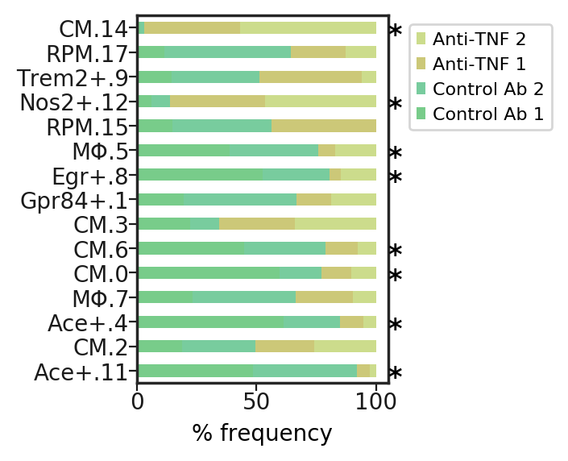

```python
admac = ad[ad.obs['treatment'].isin(['C', 'T'])]

_cta_ = 'fig3_cell_type'
groups_order = admac.obs[_cta_].unique()
total = admac[admac.obs[_cta_].isin(groups_order)].obs[[_cta_, 'batch',
    'treatment']].copy().astype(str)
df_abundance = total.groupby([_cta_, 'batch']).size().unstack().fillna(0)
Dpivot = df_abundance.div(df_abundance.sum(axis=0), axis=1)*100
Dpivot = Dpivot.div(Dpivot.sum(axis=1), axis=0)*100
Dpivot.columns = [dt[x[0]] for x in Dpivot.columns]
D = Dpivot.unstack().reset_index()
D.columns = ['treatment', 'cluster', '% frequency']

mean = D.groupby(['treatment', 'cluster']).mean()
Dplot = mean.unstack()['% frequency'].T
std = D.groupby(['treatment', 'cluster']).std()
Dplotstd = std.unstack()['% frequency'].T
order = list((mean.loc[dt['C']] - mean.loc[dt['T']]).sort_values('% frequency').index)[::-1]
corder = [dt[x] for x in ['C', 'T']]

top = mpl.cm.get_cmap('Greens', 128)
bottom = mpl.cm.get_cmap('copper', 128)
newcolors = [
        [120/255, 204/255, 138/255, 1],
        [120/255, 204/255, 158/255, 1],
        [204/255, 200/255, 120/255, 1],
        [204/255, 220/255, 140/255, 1]
        ]
newcmp = mpl.colors.ListedColormap(newcolors, name='YlGn')
res, ratio_difference = analysis.cmh_test(df_abundance.iloc[:, ::-1].loc[order], K=2)
pthreshold = 0.05

D = Dpivot.loc[yorder].copy()
D.columns = [x+' {:}'.format(i%2+1) for i, x in enumerate(D.columns)]

fig, ax = plt.subplots(figsize=(2, 3))
gfg = D.plot(kind='barh', legend=True, ax=ax, rot=0, stacked=True, xlabel='', colormap=newcmp)
handles, labels = gfg.axes.get_legend_handles_labels()
gfg.axes.legend(handles[::-1], labels[::-1], fontsize=8, bbox_to_anchor=(1.05, 1))
ax.set_ylabel(''); ax.set_xlabel('% frequency', fontsize=10); ax.set_xlim(0, 105)
ax.grid(False)
gfg.tick_params(labelsize=10, top=False, pad=0)
for i, index in enumerate(ratio_difference.loc[yorder].index):
    if (ratio_difference.loc[index, 'fdr'] <= pthreshold) & (
            abs(ratio_difference.loc[index, 'log2_ratio']) >= 1):
        ax.text(105, i-0.3, '*', va='center', weight='bold', fontsize=12,
                zorder=10);
    ratio = np.round(ratio_difference.loc[index, 'log2_ratio'], 2)
sfig(fig, fdm+'6D.bar_momac_ABCT_subset_CT_relative_abundance.vertical.fixed')
```